# Hold That Plane!

## 2.3 Missing Value Imputation

In the previous section missing values were forced in this synthetic data set to imitate the realities of data collection and standardization across this globally diverse array of airlines and airports. This knockout procedure was completed to allow for the subsequent data imputation process that will be required for real world data that contains natural missing values. When handling real world global flight delay data, all missing values must be imputed to ensure no gaps remain in the data, without completely dropping observations with missing data. This prevents overall data loss by removing the need to omit full observations based on a single missing value.

### 2.3.1 Missing Value Analysis and Intepretation

```r
missing.array <- plot_pattern(delay.clean, rotate = TRUE, caption = TRUE) +
  theme(axis.title.x.top = element_blank())
```

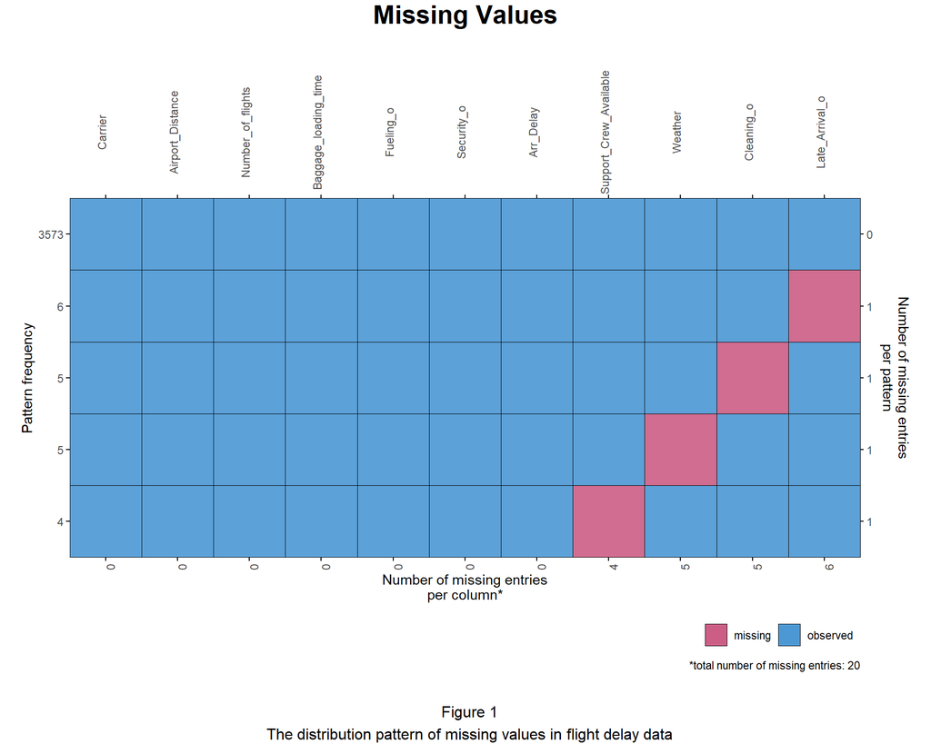

```r
grid.arrange(arrangeGrob(missing.array, ncol = 1, nrow = 1),
  top = textGrob("Missing Values
                 ", gp = gpar(fontsize = 20, fontface = "bold")),
  bottom = textGrob("
  Figure 1
  The distribution pattern of missing values in flight delay data"))
```

```r
kable(misty_test$result$little, col.names = c("# of Obs.", "# Missing Values", "# of Patterns in Missing Vals", "Statistic", "DF", "p Value"), caption = "Table 6:
      <br>Little's MCAR Test") %>%
  kable_styling()
```

Table 6: Little’s MCAR Test

| # of Obs. | # Missing Values | # of Patterns in Missing Vals | Statistic | DF | p Value |
| --- | --- | --- | --- | --- | --- |
| 3593 | 20 | 5 | 25.17261 | 40 | 0.9675297 |

```r
kable(sapply(delay.clean[c(4,5,7,8)], function (x) sum(is.na(x))), col.names = c("Variable", "Count of Missing Values"), caption = "Table 7:
<br>Summary count of missing values in each variable of the airline delay data. Variables with no missing values omitted.") %>%
  kable_styling()
```

Table 7: Summary count of missing values in each variable of the airline delay data. Variables with no missing values omitted.

| Variable | Count of Missing Values |
| --- | --- |
| Weather | 5 |
| Support_Crew_Available | 4 |
| Late_Arrival_o | 6 |
| Cleaning_o | 5 |

### 2.3.2 Multiple Imputation

While the data set utilized for this analysis had a small number of missing values, manually knocked out of the data set for the purposes of this analysis and data manipulation, real world flight data contains multitudes of gaps. In order to accurately close these missing gaps it is wiser to run an imputation model multiple times to then calculate the predicted missing values based on the multiple imputation runs, rather than relying on a single model to accurately complete all predictions, flawlessly, each time. By utilizing this approach, known as a multiple imputation model, analysts can better close the gap in airline data while accurately reflecting the model’s uncertainty based on the current quantity and pattern of missing observations. Through a multiple imputation model the variance between each imputation run can be compared to capture a measure of the model’s uncertainty.

### 2.3.3 MICE Imputation Approach

A mice imputation model was created to allow for increased flexibility in the arrival delay predictions and to allow for better preservation of relationships between variables that may not have been observed in the initial exploratory data analysis steps. This process allowed for further improved predictive power when applying these models to real world data with a larger variety of missing data patterns than observed above in `Figure 1`.

No imputation method was dictated to the MICE package to allow the package to preliminary evaluate each variable with missing data and determine the appropriate imputation approach for the individual variable. This allows for increased flexibility in imputing the data, and prevents accidentally building a model that only works with the current set of data. By allowing for this variable specific flexibility, a re-determination of the best fit imputation model is completed each time the imputation model is run. Therefore the imputation model can employ best fit approach based on the currently available data, each time the imputation is run regardless of the pattern and quantity of missing observations present. This allows for real world data tuning as new flight delay data is obtained globally. Distributions of the imputed values in each of the 5 imputation runs utilized in the MICE imputation model can be seen below in `Figure 2`.

```r
m.delay <- delay.clean[-1]
m.delay$Cleaning_o <- as.numeric(m.delay$Cleaning_o)

set.seed(122357)
mice1 <- mice(m.delay, m = 5, maxit = 10, seed = 123, print = FALSE)
mice.delay <- complete(mice1)
mice.delay$Cleaning_o <- as.factor(mice.delay$Cleaning_o)
levels(mice.delay$Cleaning_o) <- c("Immediate", "Quick", "Moderate", "Slow")
```

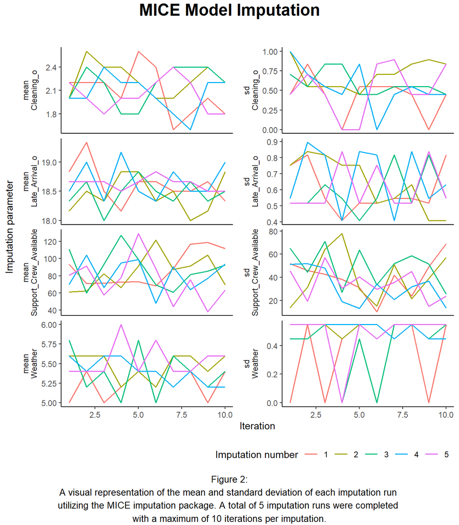

```r
mice.plot <- plot_trace(mice1)

grid.arrange(arrangeGrob(mice.plot, ncol = 1, nrow =1),
             top = textGrob("MICE Model Imputation
                            ", gp = gpar(fontsize = 18, fontface = "bold")),
             bottom = textGrob("Figure 2:
A visual representation of the mean and standard deviation of each imputation run
utilizing the MICE imputation package. A total of 5 imputation runs were completed
with a maximum of 10 iterations per imputation.", gp = gpar(fontsize = 10)))
```

```r
kable(mice1$method, col.names = c("Variable Name", "Imputation Method"), caption = "Table 8:
      <br>Imputation methods utilized for each variable.
      <br>Blank values indicate no missing observations were identified for the variable and thus no imputation was required.") %>%
  kable_styling()
```

Table 8: Imputation methods utilized for each variable. Blank values indicate no missing observations were identified for the variable and thus no imputation was required.

| Variable Name | Imputation Method |
| --- | --- |
| Airport_Distance |  |
| Number_of_flights |  |
| Weather | pmm |
| Support_Crew_Available | pmm |
| Baggage_loading_time |  |
| Late_Arrival_o | pmm |
| Cleaning_o | pmm |
| Fueling_o |  |
| Security_o |  |
| Arr_Delay |  |

$$\begin{align*}
Mean \ of \ Quanitity \ Of \ Interest's \ Means-> \ \overline{Q}
&= \sum _{i=1} ^{m} \frac{Q_i}{m} \\
Average \ Standard \ of \ Error \ of \ Quant. \ of \ Interest-> \
\overline{U} &= \sum _{i=1} ^{m} \frac{U_i}{m} \\
Variance \ of \ Mean \ of \ Quant. \ of \ Interest-> \ B &=
\frac{1}{m-1}\sum _{i=1} ^{m} (Q_i - \overline{Q})^2 \\
Estimated \ Total \ Variance \ of \ \overline{Q}-> \ T &=
\overline{U} + \frac{m + 1}{m}B
\end{align*}$$

```r
n.mice <- length(mice1$imp$Weather)

qweather.m <- c(mean(mice1$imp$Weather[,1]), mean(mice1$imp$Weather[,2]), mean(mice1$imp$Weather[,3]), mean(mice1$imp$Weather[,4]),
                     mean(mice1$imp$Weather[,5]))
uweather.m <- c(std.error(mice1$imp$Weather[,1]), std.error(mice1$imp$Weather[,2]), std.error(mice1$imp$Weather[,3]),
                std.error(mice1$imp$Weather[,4]), std.error(mice1$imp$Weather[,5]))
q.bar.weather.m <- mean(qweather.m)
u.bar.weather.m <- mean(uweather.m)
b.weather.m <- var(qweather.m)
t.weather.m <- (q.bar.weather.m + ((n.mice + 1)/n.mice)*b.weather.m)
se.weather.m <- std.error(qweather.m)


qsupcrew.m <- c(mean(mice1$imp$Support_Crew_Available[,1]), mean(mice1$imp$Support_Crew_Available[,2]), mean(mice1$imp$Support_Crew_Available[,3]),
                mean(mice1$imp$Support_Crew_Available[,4]), mean(mice1$imp$Support_Crew_Available[,5]))
usupcrew.m <- c(std.error(mice1$imp$Support_Crew_Available[,1]), std.error(mice1$imp$Support_Crew_Available[,2]),
                std.error(mice1$imp$Support_Crew_Available[,3]), std.error(mice1$imp$Support_Crew_Available[,4]),
                std.error(mice1$imp$Support_Crew_Available[,5]))
q.bar.supcrew.m <- mean(qsupcrew.m)
u.bar.supcrew.m <- mean(usupcrew.m)
b.supcrew.m <- var(qsupcrew.m)
t.supcrew.m <- (q.bar.supcrew.m + ((n.mice + 1)/n.mice)*b.supcrew.m)
se.supcrew.m <- std.error(qsupcrew.m)

qlateincom.m <- c(mean(mice1$imp$Late_Arrival_o[,1]), mean(mice1$imp$Late_Arrival_o[,2]), mean(mice1$imp$Late_Arrival_o[,3]),
                  mean(mice1$imp$Late_Arrival_o[,4]), mean(mice1$imp$Late_Arrival_o[,5]))
ulateincom.m <- c(std.error(mice1$imp$Late_Arrival_o[,1]), std.error(mice1$imp$Late_Arrival_o[,2]), std.error(mice1$imp$Late_Arrival_o[,3]),
                  std.error(mice1$imp$Late_Arrival_o[,4]), std.error(mice1$imp$Late_Arrival_o[,5]))
q.bar.lateincom.m <- mean(qlateincom.m)
u.bar.lateincom.m <- mean(ulateincom.m)
b.lateincom.m <- var(qlateincom.m)
t.lateincom.m <- (q.bar.lateincom.m + ((n.mice + 1)/n.mice)*b.lateincom.m)
se.lateincom.m <- std.error(qlateincom.m)

qclean.m <- c(mean(mice1$imp$Cleaning_o[,1]), mean(mice1$imp$Cleaning_o[,2]), mean(mice1$imp$Cleaning_o[,3]), mean(mice1$imp$Cleaning_o[,4]),
                     mean(mice1$imp$Cleaning_o[,5]))
uclean.m <- c(std.error(mice1$imp$Cleaning_o[,1]), std.error(mice1$imp$Cleaning_o[,2]), std.error(mice1$imp$Cleaning_o[,3]),
                std.error(mice1$imp$Cleaning_o[,4]), std.error(mice1$imp$Cleaning_o[,5]))
q.bar.clean.m <- mean(qclean.m)
u.bar.clean.m <- mean(uclean.m)
b.clean.m <- var(qclean.m)
t.clean.m <- (q.bar.clean.m + ((n.mice + 1)/n.mice)*b.clean.m)
se.clean.m <- std.error(qclean.m)


mice.merge <- data.frame(
    Statistic = c("Q.bar", "U.bar", "B.var", "T", "Std.Err"),
    mice.weather = c(q.bar.weather.m, u.bar.weather.m, b.weather.m, t.weather.m, se.weather.m),
    mice.sup.crew = c(q.bar.supcrew.m, u.bar.supcrew.m, b.supcrew.m, t.supcrew.m, se.supcrew.m),
    mice.late.incoming = c(q.bar.lateincom.m, u.bar.lateincom.m, b.lateincom.m, t.lateincom.m, se.lateincom.m),
    mice.clean = c(q.bar.clean.m, u.bar.clean.m, b.clean.m, t.clean.m, se.clean.m)
)
```

```r
kable(mice.merge, col.names = c("Statistic", var.details[4,1], var.details[5,1], var.details[7,1], var.details[8,1]) , caption = "Table 9:
      <br>
      Summary statistics using Ruben's Rules for MICE Imputation for missing values in global flight delay data <br> number of imputations (m) = 5 <br> maximum iterations (maxit) = 10") %>%
  kable_styling()
```

Table 9: Summary statistics using Ruben’s Rules for MICE Imputation for missing values in global flight delay data number of imputations (m) = 5 maximum iterations (maxit) = 10

| Statistic | Weather | Support Crews Available | Late Incoming Plane Arrival | Cleaning Time |
| --- | --- | --- | --- | --- |
| Q.bar | 5.4400000 | 86.150000 | 18.6333333 | 2.0400000 |
| U.bar | 0.2359592 | 18.894378 | 0.2410825 | 0.2696663 |
| B.var | 0.0280000 | 382.737500 | 0.0750000 | 0.0480000 |
| T | 5.4736000 | 545.435000 | 18.7233333 | 2.0976000 |
| Std.Err | 0.0748331 | 8.749143 | 0.1224745 | 0.0979796 |

```r
kable(summary(delay.clean[, c(4, 5, 7, 8)]), col.names = c(var.details[4,1], var.details[5,1], var.details[7,1], var.details[8,1]), caption = "Table 10.a:
<br>Summary statistics of variables with missing values before MICE imputation") %>%
  kable_styling()
```

Table 10.a: Summary statistics of variables with missing values before MICE imputation

|  | Weather | Support Crews Available | Late Incoming Plane Arrival | Cleaning Time |
| --- | --- | --- | --- | --- |
|  | Min. :5.000 | Min. : 0 | Min. :15.00 | Immediate: 517 |
|  | 1st Qu.:5.000 | 1st Qu.: 56 | 1st Qu.:18.00 | Quick :2261 |
|  | Median :5.000 | Median : 83 | Median :19.00 | Moderate : 780 |
|  | Mean :5.354 | Mean : 85 | Mean :18.74 | Slow : 30 |
|  | 3rd Qu.:6.000 | 3rd Qu.:112 | 3rd Qu.:19.00 | NA’s : 5 |
|  | Max. :6.000 | Max. :222 | Max. :22.00 | NA |
|  | NA’s :5 | NA’s :4 | NA’s :6 | NA |

```r
kable(summary(mice.delay[, c(3, 4, 6, 7)]), col.names = c(var.details[4,1], var.details[5,1], var.details[7,1], var.details[8,1]), caption = "Table 10.b:
<br>Summary statistics of variables with missing values after MICE imputation") %>%
  kable_styling()
```

Table 10.b: Summary statistics of variables with missing values after MICE imputation

|  | Weather | Support Crews Available | Late Incoming Plane Arrival | Cleaning Time |
| --- | --- | --- | --- | --- |
|  | Min. :5.000 | Min. : 0.00 | Min. :15.00 | Immediate: 518 |
|  | 1st Qu.:5.000 | 1st Qu.: 56.00 | 1st Qu.:18.00 | Quick :2265 |
|  | Median :5.000 | Median : 83.00 | Median :19.00 | Moderate : 780 |
|  | Mean :5.354 | Mean : 85.03 | Mean :18.74 | Slow : 30 |
|  | 3rd Qu.:6.000 | 3rd Qu.:112.00 | 3rd Qu.:19.00 | NA |
|  | Max. :6.000 | Max. :222.00 | Max. :22.00 | NA |

# 3 Exploratory Data Analysis (EDA)

## 3.1 Skew and Distribuion Check

In order to determine if any of the variable data is skewed, the continuous variable distributions were plotted with an overlay indicating the standard normal distribution as calculated with the respective variable’s calculated mean and standard deviation. This check was completed to ensure the data as available will cooperate with the prediction models utilized later in the analysis. As a majority of prediction models require the assumption of a normal distribution, the calculated normal distribution curve for each respective variable was overlaid as a comparison reference. In order to properly leverage the prediction models to optimize airport planning to reduce flight delays, it is imperative to ensure the data fits within the assumptions of the prediction model utilized.

```r
dist_dens <- ggplot(mice.delay, aes(x = Airport_Distance)) +
  geom_density(fill = "blue", alpha = 0.5) +
  stat_function(fun = dnorm, args = list(mean = mean(mice.delay$Airport_Distance), sd = sd(mice.delay$Airport_Distance)), color = "darkred", linewidth = 1, linetype = "dashed") +
  geom_vline(aes(xintercept = mean(mice.delay$Airport_Distance)), color = "black") +
  geom_vline(aes(xintercept = median(mice.delay$Airport_Distance)), color = "black", linetype = "dashed") +
  labs(title = "Distance Between Departure-Arrival Airports",
       x = "Distance (miles)",
       y = "Density")

numflight_dens <- ggplot(mice.delay, aes(x = Number_of_flights)) +
  geom_density(fill = "blue", alpha = 0.5) +
  stat_function(fun = dnorm, args = list(mean = mean(mice.delay$Number_of_flights), sd = sd(mice.delay$Number_of_flights)), color = "darkred", linewidth = 1, linetype = "dashed") +
  geom_vline(aes(xintercept = mean(mice.delay$Number_of_flights)), color = "black") +
  geom_vline(aes(xintercept = median(mice.delay$Number_of_flights)), color = "black", linetype = "dashed") +
  labs(title = "Total Flights per Airport *",
       x = "Flights per Airport",
       y = NULL)

supcrew_dens <- ggplot(mice.delay, aes(x = Support_Crew_Available)) +
  geom_density(fill = "blue", alpha = 0.5) +
  stat_function(fun = dnorm, args = list(mean = mean(mice.delay$Support_Crew_Available), sd = sd(mice.delay$Support_Crew_Available, na.rm = TRUE)), color = "darkred", linewidth = 1, linetype = "dashed") +
  geom_vline(aes(xintercept = mean(mice.delay$Support_Crew_Available)), color = "black") +
  geom_vline(aes(xintercept = median(mice.delay$Support_Crew_Available)), color = "black", linetype = "dashed") +
  labs(title = "Total Support Crew Members Available *",
       x = "Support Crew Available",
       y = NULL)

fueling_dens <- ggplot(mice.delay, aes(x = Fueling_o)) +
  geom_density(fill = "blue", alpha = 0.5) +
  stat_function(fun = dnorm, args = list(mean = mean(mice.delay$Fueling_o), sd = sd(mice.delay$Fueling_o)), color = "darkred", linewidth = 1, linetype = "dashed") +
  geom_vline(aes(xintercept = mean(mice.delay$Fueling_o)), color = "black") +
  geom_vline(aes(xintercept = median(mice.delay$Fueling_o)), color = "black", linetype = "dashed") +
  labs(title = "Plane Fueling Times",
       x = "Fueling Time (minutes)",
       y = NULL)

security_dens <- ggplot(mice.delay, aes(x = Security_o)) +
  geom_density(fill = "blue", alpha = 0.5) +
  stat_function(fun = dnorm, args = list(mean = mean(mice.delay$Security_o), sd = sd(mice.delay$Security_o)), color = "darkred", linewidth = 1, linetype = "dashed") +
  geom_vline(aes(xintercept = mean(mice.delay$Security_o)), color = "black") +
  geom_vline(aes(xintercept = median(mice.delay$Security_o)), color = "black", linetype = "dashed") +
  labs(title = "Total Security Times",
       x = "Time (minutes)",
       y = "Density")

arrival_dens <- ggplot(mice.delay, aes(x = Arr_Delay)) +
  geom_density(fill = "blue", alpha = 0.5) +
  stat_function(fun = dnorm, args = list(mean = mean(mice.delay$Arr_Delay), sd = sd(mice.delay$Arr_Delay)), color = "darkred", linewidth = 1, linetype = "dashed") +
  geom_vline(aes(xintercept = mean(mice.delay$Arr_Delay)), color = "black") +
  geom_vline(aes(xintercept = median(mice.delay$Arr_Delay)), color = "black", linetype = "dashed") +
  labs(title = "Total Flight Delays",
       x = "Duration (minutes)",
       y = "Density")

lateincom_dens <- ggplot(mice.delay, aes(x = Late_Arrival_o)) +
  geom_density(fill = "blue", alpha = 0.5) +
  stat_function(fun = dnorm, args = list(mean = mean(mice.delay$Late_Arrival_o), sd = sd(mice.delay$Late_Arrival_o)), color = "darkred", linewidth = 1, linetype = "dashed") +
  geom_vline(aes(xintercept = mean(mice.delay$Late_Arrival_o)), color = "black") +
  geom_vline(aes(xintercept = median(mice.delay$Late_Arrival_o)), color = "black", linetype = "dashed") +
  labs(title = "Late Incomig Plane Delays *",
       x = "Duration (minutes)",
       y = "Density")

weather_dens <- ggplot(mice.delay, aes(x = Weather)) +
  geom_density(fill = "blue", alpha = 0.5) +
  stat_function(fun = dnorm, args = list(mean = mean(mice.delay$Weather), sd = sd(mice.delay$Weather)), color = "darkred", linewidth = 1, linetype = "dashed") +
  geom_vline(aes(xintercept = mean(mice.delay$Weather)), color = "black") +
  geom_vline(aes(xintercept = median(mice.delay$Weather)), color = "black", linetype = "dashed") +
  labs(title = "Weather Conditions",
       x = "Ranking of Weather Severity",
       y = "Density")
```

```r
baggage_bar <- ggplot(mice.delay, aes(x = Baggage_loading_time)) +
  geom_bar(fill = "blue", alpha = 0.5) +
  labs(title = "Baggage Loading Times *",
       x = "Loading Duration (slowest to fastest from left to right)",
       y = "Frequency")

cleaning_bar <- ggplot(mice.delay, aes(x = Cleaning_o)) +
  geom_bar(fill = "blue", alpha = 0.5) +
  labs(title = "Plane Cleaning Times *",
       x = "Cleaning Duration (slowest to fastest from left to right)",
       y = NULL)
```

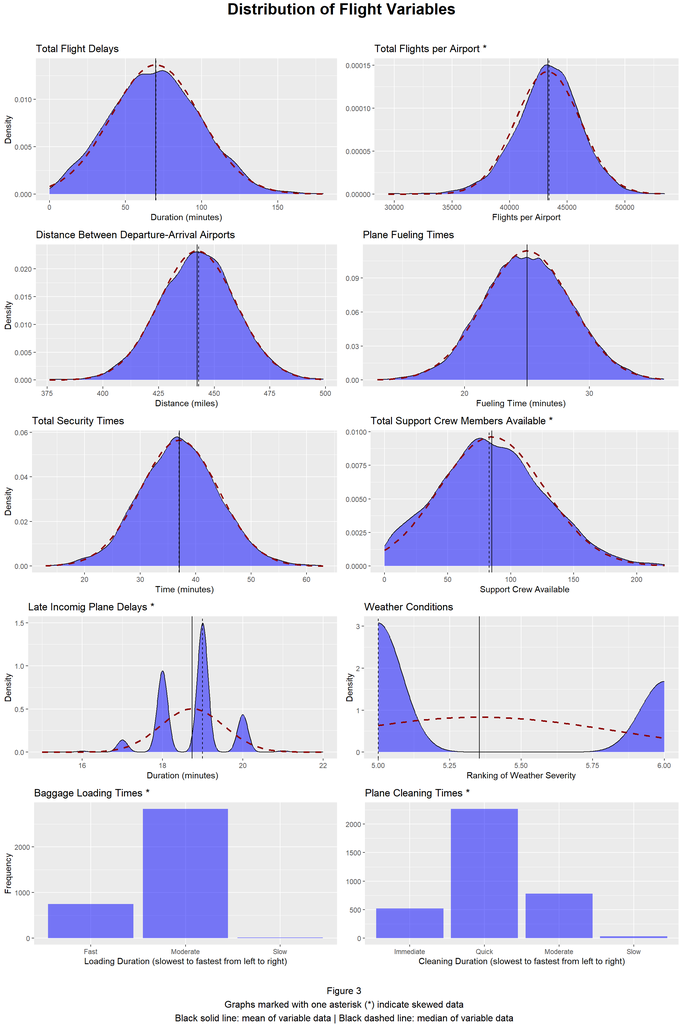

```r
grid.arrange(
  arrangeGrob(arrival_dens, numflight_dens, dist_dens, fueling_dens, security_dens, supcrew_dens, lateincom_dens, weather_dens, baggage_bar, cleaning_bar, ncol = 2,nrow = 5),
  top = textGrob("Distribution of Flight Variables
                 ", gp = gpar(fontsize = 20, fontface = "bold")),
  bottom = textGrob("
  Figure 3
  Graphs marked with one asterisk (*) indicate skewed data
  Black solid line: mean of variable data | Black dashed line: median of variable data"))
```

### 3.1.1 Understanding the Skew

In order to confirm the visually identified data skews the means and medians of the following variables were compared:

- Number of Flights
- Support Crews Available
- Late Incoming Planes
- Baggage Loading Time
- Cleaning

Upon comparison of the mean and median of the numeric variables it was identified that the late incoming planes variable was not skewed as the median and mean were identical. Frequency counts for the categorical variables also identified that the mode of these variables corroborated a normal distribution. This left the number of flights and support crews available as the two truly skewed variables requiring transformation.

```r
kable(summary(round(mice.delay[c(2,4,6)]), digits = 1), caption = "Table 11:
<br>Summary statistics for variables with skewed distributions. Rounded to whole numbers as the fractions of flights and fractions of support crew members cannot exist naturally.", col.names = c(var.details[3,1], var.details[5,1], var.details[7,1])) %>%
  kable_styling()
```

Table 11: Summary statistics for variables with skewed distributions. Rounded to whole numbers as the fractions of flights and fractions of support crew members cannot exist naturally.

|  | Number of Flights | Support Crews Available | Late Incoming Plane Arrival |
| --- | --- | --- | --- |
|  | Min. :29475 | Min. : 0 | Min. :15 |
|  | 1st Qu.:41634 | 1st Qu.: 56 | 1st Qu.:18 |
|  | Median :43424 | Median : 83 | Median :19 |
|  | Mean :43311 | Mean : 85 | Mean :19 |
|  | 3rd Qu.:45140 | 3rd Qu.:112 | 3rd Qu.:19 |
|  | Max. :53461 | Max. :222 | Max. :22 |

```r
kable(summary(mice.delay[c(5, 7)]), caption = "Table 12:
<br>Frequency count to capture the mode of categorical variables with skewed distributions.", col.names = c(var.details[6,1], var.details[8,1])) %>%
  kable_styling()
```

Table 12: Frequency count to capture the mode of categorical variables with skewed distributions.

|  | Baggage Loading Time | Cleaning Time |
| --- | --- | --- |
|  | Fast : 749 | Immediate: 518 |
|  | Moderate:2833 | Quick :2265 |
|  | Slow : 11 | Moderate : 780 |
|  | NA | Slow : 30 |

### 3.1.2 Skew Correction Trough Variable Normalization

In order to normalize the variables for future predictive model use, min-max normalization was employed to reduce all variables to a range of [0,1]. The categorical variables were already encoded as factor variables, allowing for easy label encoding to allow for cooperation with the min-max standardization. The following equation was applied to all numeric variables (both originally numeric and forced numeric from factor categorical variables).

$$x_{standardized} = \frac{x -
min(x)}{max(x) - min(x)}$$

```r
mice.delay$cleaning <- as.numeric(mice.delay$Cleaning_o)
mice.delay$baggage <- as.numeric(mice.delay$Baggage_loading_time)

delay.std <- data.frame(
  airport_dist = (mice.delay$Airport_Distance - min(mice.delay$Airport_Distance)) / (max(mice.delay$Airport_Distance) - min(mice.delay$Airport_Distance)),
  num_flights = (mice.delay$Number_of_flights - min(mice.delay$Number_of_flights)) / (max(mice.delay$Number_of_flights) - min(mice.delay$Number_of_flights)),
  weather = (mice.delay$Weather - min(mice.delay$Weather)) / (max(mice.delay$Weather) - min(mice.delay$Weather)),
  sup_crew = (mice.delay$Support_Crew_Available - min(mice.delay$Support_Crew_Available)) / (max(mice.delay$Support_Crew_Available) - min(mice.delay$Support_Crew_Available)),
  late_incoming = (mice.delay$Late_Arrival_o - min(mice.delay$Late_Arrival_o)) / (max(mice.delay$Late_Arrival_o) - min(mice.delay$Late_Arrival_o)),
  fueling = (mice.delay$Fueling_o - min(mice.delay$Fueling_o)) / (max(mice.delay$Fueling_o) - min(mice.delay$Fueling_o)),
  security = (mice.delay$Security_o - min(mice.delay$Security_o)) / (max(mice.delay$Security_o) - min(mice.delay$Security_o)),
  arr_delay = (mice.delay$Arr_Delay - min(mice.delay$Arr_Delay)) / (max(mice.delay$Arr_Delay) - min(mice.delay$Arr_Delay)),
  cleaning = (mice.delay$cleaning - min(mice.delay$cleaning)) / (max(mice.delay$cleaning) - min(mice.delay$cleaning)),
  baggage = (mice.delay$baggage - min(mice.delay$baggage)) / (max(mice.delay$baggage) - min(mice.delay$baggage))
)
```

```r
kable(summary(delay.std), col.names = c(var.details[2,1], var.details[3,1], var.details[4,1], var.details[5,1], var.details[6,1], var.details[7,1], var.details[8,1], var.details[9,1], var.details[10,1], var.details[11,1]), caption = "Table 13:
      <br>Summary statistics of normalized flight data") %>%
  kable_styling() %>%
  scroll_box(width = "100%")
```

Table 13: Summary statistics of normalized flight data

|  | Airport Distance | Number of Flights | Weather | Support Crews Available | Baggage Loading Time | Late Incoming Plane Arrival | Cleaning Time | Fueling Time | Security Time | Overall Flight Delay |
| --- | --- | --- | --- | --- | --- | --- | --- | --- | --- | --- |
|  | Min. :0.0000 | Min. :0.0000 | Min. :0.0000 | Min. :0.0000 | Min. :0.0000 | Min. :0.0000 | Min. :0.0000 | Min. :0.0000 | Min. :0.0000 | Min. :0.0000 |
|  | 1st Qu.:0.4472 | 1st Qu.:0.5069 | 1st Qu.:0.0000 | 1st Qu.:0.2523 | 1st Qu.:0.4286 | 1st Qu.:0.4348 | 1st Qu.:0.3800 | 1st Qu.:0.2722 | 1st Qu.:0.3333 | 1st Qu.:0.5000 |
|  | Median :0.5447 | Median :0.5815 | Median :0.0000 | Median :0.3739 | Median :0.5714 | Median :0.5217 | Median :0.4800 | Median :0.3889 | Median :0.3333 | Median :0.5000 |
|  | Mean :0.5395 | Mean :0.5768 | Mean :0.3537 | Mean :0.3830 | Mean :0.5341 | Mean :0.5222 | Mean :0.4817 | Mean :0.3878 | Mean :0.3632 | Mean :0.3973 |
|  | 3rd Qu.:0.6341 | 3rd Qu.:0.6531 | 3rd Qu.:1.0000 | 3rd Qu.:0.5045 | 3rd Qu.:0.5714 | 3rd Qu.:0.6087 | 3rd Qu.:0.5800 | 3rd Qu.:0.5000 | 3rd Qu.:0.3333 | 3rd Qu.:0.5000 |
|  | Max. :1.0000 | Max. :1.0000 | Max. :1.0000 | Max. :1.0000 | Max. :1.0000 | Max. :1.0000 | Max. :1.0000 | Max. :1.0000 | Max. :1.0000 | Max. :1.0000 |

Min-max normalization was chosen to allow for future use with feature magnitude sensitive algorithms, such as k Nearest Neighbors cluster analysis.

## 3.2 Feature Selection

A visualization of the importance of each variable in potential prediction of overall flight delays is included below in `Figure 4`. As demonstrated below there is a steep drop off in importance for total cleaning time (cleaning), fueling times (fueling), & security times (security); therefore these variables will be omitted from future analysis to reduce computational burden and prevent redundancies.

```r
x.caret <- delay.std[,-8]
y.caret <- delay.std[,8]

set.seed(12345)
inTrain <- createDataPartition(y.caret, p = 0.80, list = FALSE)[,1]

x.caret.train <- x.caret[inTrain, ]
x.caret.test <- x.caret[-inTrain, ]
y.caret.train <- y.caret[inTrain]
y.caret.test <- y.caret[-inTrain]


control <- rfeControl(functions = rfFuncs, method = "cv", repeats = 5, number = 10)

delay.caret <- rfe(x = x.caret.train, y.caret.train , sizes = c(1:5), rfeControl = control)
```

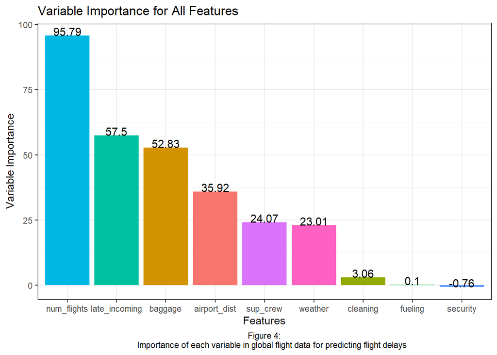

```r
delay.caret.var <- data.frame(feature = row.names(varImp(delay.caret))[1:9],
                              importance = varImp(delay.caret)[1:9, 1])

accuracy.caret <- postResample(predict(delay.caret, x.caret.test), y.caret.test)

ggplot(delay.caret.var, aes(x = reorder(feature, -importance), y = importance, fill = feature)) +
  geom_bar(stat="identity") +
  labs(x = "Features", y = "Variable Importance", title = "Variable Importance for All Features", caption = "Figure 4:
       Importance of each variable in global flight data for predicting flight delays") +
  geom_text(aes(label = round(importance, 2)), vjust = 0, color = "black", size = 4) +
  theme_bw() +
  theme(legend.position = "none",
        plot.caption = element_text(hjust = 0.5))
```

## 3.3 Feature Creation

In order to properly utilize the 6 most important variables for prediction of overall flight delays as outlined above in `Figure 4` a two step feature creation process was utilized. Initially a principal component analysis was conducted to combine these 6 variables into principal components that capture a combination of these 6 variables. Utilizing the PCA approach allows for a more streamlined approach for creating prediction models for overall flight delay times. Once transformed into principal components, a k-means cluster analysis was then conducted to add for an additional feature to utilize when creating flight delay prediction models.

### 3.3.1 Principal Component Analysis

Utilizing the most important variables as identified in `Figure 4` (number of flights per airport, late incoming plane, baggage loading time, distance between airports, support crews available, and weather) a principal component analysis was conducted to further reduce redundancies. An initial scree plot (`Figure 5`) was utilized to determine the “elbow” cutoff of PC1 & PC2 where the variance steeply cuts off. Upon calculation of the total percentage of variance, it was found that in order to create a model that accounts for >80% of the variance in the total flight delay data, the first 4 PCs must be utilized.

```r
delay.std.km <- delay.std[,-c(6, 7,9)]

pca.delay <- prcomp(delay.std.km[,-6], scale = TRUE)
pca.delay.1 <- cbind(delay.std.km, pca.delay$x)

pca.var <- apply(pca.delay$x, 2, var)
```

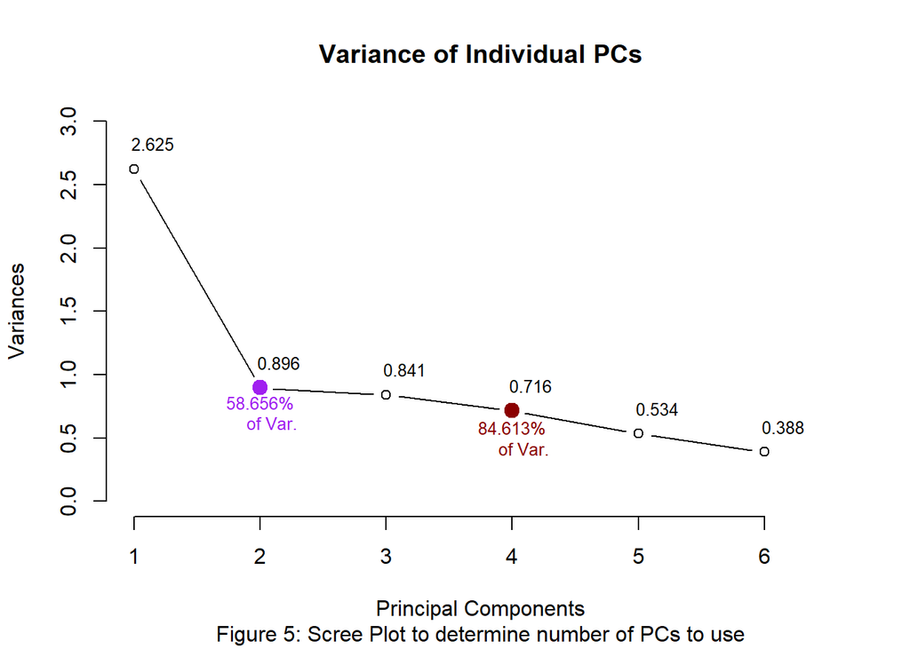

```r
eigen.pca <- summary(pca.delay)


plot(pca.delay, type ="l", ylim=c(0,3), xlim=c(1,6.5), main = NULL)
text((1:10)+0.15, pca.var+0.2, as.character(round(pca.var, 3)), cex = 0.8)
title(main = "Variance of Individual PCs", xlab ="Principal Components", sub = "Figure 5: Scree Plot to determine number of PCs to use")
points(x = 2, y = (pca.delay$sdev[2])^2, pch = 19, col = "purple", cex = 1.5)
text(x = 2, y = 0.7, "58.656%
     of Var.", col = "purple", cex = 0.8)
points(x = 4, y = (pca.delay$sdev[4])^2, pch = 19, col = "darkred", cex = 1.5)
text(x = 4, y = 0.5, "84.613%
     of Var.", col = "darkred", cex = 0.8)
```

```r
kable(pca.delay$rotation[,c(1:5)], caption = "Table 14:
      <br>Principal Component Coefficients (rotation matrix)") %>%
  kable_styling()
```

Table 14: Principal Component Coefficients (rotation matrix)

|  | PC1 | PC2 | PC3 | PC4 | PC5 |
| --- | --- | --- | --- | --- | --- |
| airport_dist | 0.3706110 | 0.0899273 | -0.4517494 | 0.7958560 | -0.0373642 |
| num_flights | 0.5153757 | 0.0539246 | -0.1114829 | -0.1796823 | -0.0161651 |
| weather | 0.2584309 | -0.8926859 | 0.3298843 | 0.1642819 | 0.0014252 |
| sup_crew | -0.2986655 | -0.4333072 | -0.8063486 | -0.2590790 | 0.0564256 |
| late_incoming | 0.4674321 | 0.0237125 | -0.1323775 | -0.3910015 | -0.6664500 |
| baggage | 0.4717573 | 0.0616424 | -0.0833575 | -0.2955247 | 0.7422945 |

```r
kable(eigen.pca$importance, caption = "Table 15:
      <br>Variance captured by each principal component, as calculated by using eigenvalues") %>%
  kable_styling()
```

Table 15: Variance captured by each principal component, as calculated by using eigenvalues

|  | PC1 | PC2 | PC3 | PC4 | PC5 | PC6 |
| --- | --- | --- | --- | --- | --- | --- |
| Standard deviation | 1.620099 | 0.9463168 | 0.9171852 | 0.8463776 | 0.7307255 | 0.6230744 |
| Proportion of Variance | 0.437450 | 0.1492500 | 0.1402000 | 0.1193900 | 0.0889900 | 0.0647000 |
| Cumulative Proportion | 0.437450 | 0.5867100 | 0.7269100 | 0.8463000 | 0.9353000 | 1.0000000 |

### 3.3.2 k-Means Clustering Feature Creation

```r
kmeans.wss <- fviz_nbclust(pca.delay.1[-c(1:7, 12:13)], FUN = hcut, method = "wss")
kmeans.sil <- fviz_nbclust(pca.delay.1[-c(1:7, 12:13)], FUN = hcut, method = "silhouette")
```

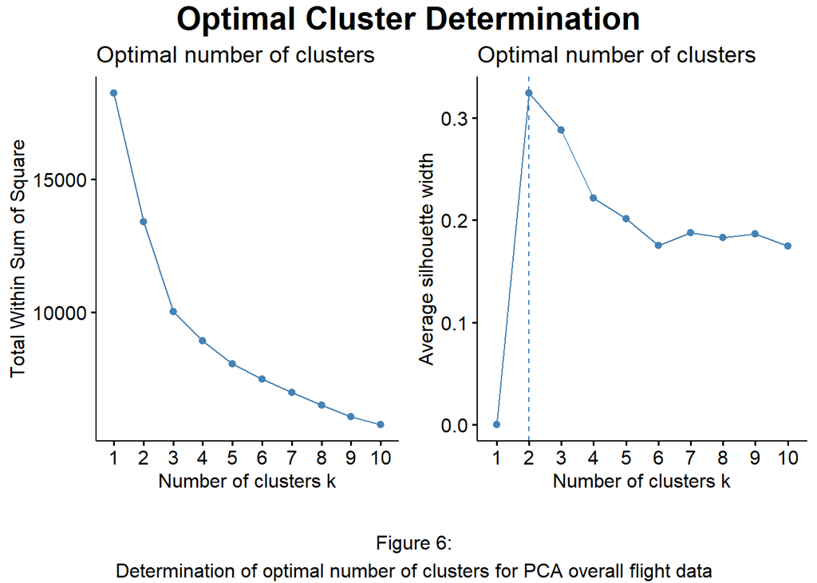

```r
grid.arrange(
  arrangeGrob(kmeans.wss, kmeans.sil, ncol = 2,nrow = 1),
  top = textGrob("Optimal Cluster Determination", gp = gpar(fontsize = 20, fontface = "bold")),
  bottom = textGrob("
  Figure 6:
  Determination of optimal number of clusters for PCA overall flight data"))
```

```r
set.seed(12345)
pca.delay.1$cluster <- kmeans(pca.delay.1[-c(1:7, 12:13)], centers =  2, nstart = 25)$cluster
pca.delay.1$centers <- kmeans(pca.delay.1[-c(1:7, 12:13)], centers =  2, nstart = 25)$center[1]
```

```r
eigen <- round(get_eigenvalue(pca.delay), 1)
var.eigen <- eigen$variance.percent
cluster_centers <- aggregate(pca.delay.1, by=list(cluster = pca.delay.1$cluster), FUN = mean)
pca.delay.1$cluster <- as.factor(pca.delay.1$cluster)
```

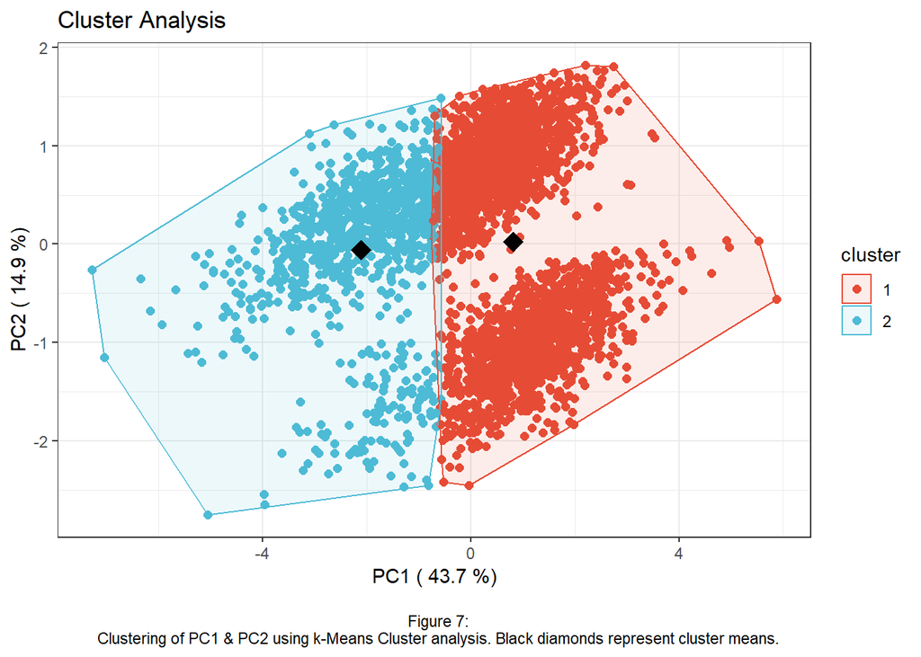

```r
ggscatter(pca.delay.1, x = "PC1", y = "PC2",
          color = "cluster",
          palette = "npg",
          ellipse = TRUE,
          ellipse.type = "convex",
          legend = "right",
          xlab = paste("PC1 (",var.eigen[1],"%)"),
          ylab = paste("PC2 (", var.eigen[2],"%)")) +
  geom_point(x = cluster_centers$PC1[1], y = cluster_centers$PC2[1], shape = 18, size = 5, color = "black") +
  geom_point(x = cluster_centers$PC1[2], y = cluster_centers$PC2[2], shape = 18, size = 5, color = "black") +
  labs(title = "Cluster Analysis", caption = "
  Figure 7:
  Clustering of PC1 & PC2 using k-Means Cluster analysis. Black diamonds represent cluster means.") +
  theme_bw() +
  theme(plot.caption = element_text(hjust = 0.5))
```

# 4 Linear Regression Model for Arrival Delay Prediction

## 4.1 Regression Model Creation

```r
final.delay <- pca.delay.1[-c(12:13, 15)]
final.delay$cluster <- as.numeric(final.delay$cluster)

lm.delay.full <- lm(arr_delay ~ ., data = final.delay)
lm.delay.step <- step(lm.delay.full, direction = "both", trace = 0)
```

## 4.2 Model Comparrison Through Cross Validation

With all four potential regression models created, 5-fold cross validation was conducted to calculate the Mean Square Error (MSE) of each validation run, followed by the mean MSE of all validation runs per prediction model. The data was split 80:20 into train:test data subsets respectively, utilizing the training subsets for the cross validation process. Through comparing the calculated training data mean MSE values, the best fit prediction model was selected for further testing utilizing the test data. As MSE represents the mean squared distance between the model’s predicted value and the actual associated data value, MSE can be utilized to compare the prediction accuracy of linear regression models and identify the best model for selection (lower MSE = more accurate model).

As identified below in `Figure 8` and `Table 16`, model 2 returned the lowest mean MSE and lowest individual MSE values for each cross-validation fold; therefore model 2 (PCA model) was selected as the primary prediction model for live overall arrival delay times. As discussed earlier in section 3.3.1 Principal Component Analysis, each principal component contains a finely tuned transformation of all important variables in the global flight delay data. This holistic approach supports the returned results of model 2 returning the lowest MSE as the PCA component of this model was preliminary tuned for this purpose. Additionally the k-Means cluster ID was created utilizing only the created PCA components, further ensuring all aspects of the normalized data is represented in the regression model with minimal noise.

```r
set.seed(123)
#shuffling the data
n <- dim(final.delay)[1] #set sample size
obs.ID <- 1:n   #create observation ID to allow for random splitting
n.train <- round(0.8*n)  #create sample size for training data. round to keep whole number since no partial observations

shuffle.id  <-  sample(obs.ID, n, replace = FALSE)  #randomize created observation ID, does not allow for dupes in list.

shuffle.delay <- final.delay[shuffle.id, ] #orders rows of dataframe to be in order of shuffle.id created random obs.id list

#splitting the data

train.data <- shuffle.delay[1:n.train, ] #splitting shuffled data from 1st obs to end of training data (80%)
test.data <- shuffle.delay[(n.train + 1):n, ] #splitting shuffled data from 1st obs after end of training data to end of remaining data (test)

n.fold <- round(n.train/5)-1   #number of observations in each of the 5 folds of validation


#validation loop - 5 fold

mse.lin.1 <- rep(0,5)
mse.lin.2 <- rep(0,5)
mse.lin.3 <- rep(0,5)
mse.lin.4 <- rep(0,5)

for (i in 1:5){
  valid.id = ((i-1) * n.fold + 1):(1 * n.fold)  #breaks down folds into 5 groups
  lin.train = train.data[-valid.id, ]
  lin.valid = train.data[valid.id, ]

  #building models to run off of folded data
  m1 = lm(arr_delay ~ . , data = lin.train)
  m2 = lm(arr_delay ~ PC1 + cluster, data = lin.train)
  m3 = lm(arr_delay ~ airport_dist + num_flights + weather + sup_crew + late_incoming + baggage + cluster, data = lin.train)
  m4 = lm(arr_delay ~ late_incoming + num_flights + baggage + cluster, data = lin.train)

  #predicting flight delay using models
  predm1 = predict(m1, newdata = lin.train)
  predm2 = predict(m2, newdata = lin.train)
  predm3 = predict(m3, newdata = lin.train)
  predm4 = predict(m4, newdata = lin.train)

  #calculate mean square error between predicted values and values from validation data
  mse.lin.1[i] = mean((predm1 - lin.valid$arr_delay)^2)
  mse.lin.2[i] = mean((predm2 - lin.valid$arr_delay)^2)
  mse.lin.3[i] = mean((predm3 - lin.valid$arr_delay)^2)
  mse.lin.4[i] = mean((predm4 - lin.valid$arr_delay)^2)
}

l.mse.1 = mean(mse.lin.1)
l.mse.2 = mean(mse.lin.2)
l.mse.3 = mean(mse.lin.3)
l.mse.4 = mean(mse.lin.4)
```

```r
mse.mod1 <- data.frame (
  x = 1:5,
  y = mse.lin.1
)
mse.mod2 <- data.frame (
  x = 1:5,
  y = mse.lin.2
)
mse.mod3 <- data.frame (
  x = 1:5,
  y = mse.lin.3
)
mse.mod4 <- data.frame (
  x = 1:5,
  y = mse.lin.4
)
mse.mod1.plot <- ggplot (mse.mod1, aes(x = x, y = y)) +
  geom_point(aes(x = mse.mod1$x, mse.mod1$y, color = "Model 1"))+
  geom_line(aes(x = mse.mod1$x, mse.mod1$y, color = "Model 1")) +
  geom_point (aes (x = mse.mod2$x, y = mse.mod2$y, color = "Model 2")) +
  geom_line (aes (x = mse.mod2$x, y = mse.mod2$y, color = "Model 2")) +
  geom_point(aes(x = mse.mod3$x, y = mse.mod3$y, color = "Model 3"))+
  geom_line (aes(x = mse.mod3$x, y = mse.mod3$y, color = "Model 3"), linetype = "longdash") +
  geom_point(aes(x = mse.mod4$x, y = mse.mod4$y, color = "Model 4"))+
  geom_line (aes(x = mse.mod4$x, y = mse.mod4$y, color = "Model 4")) +
  labs (x = "Validation Fold", y = "Calculated MSE") +
  scale_color_manual (values = c("Model 1" = "black", "Model 2" = "blue", "Model 3" = "deeppink", "Model 4" = "orange4" ))+
  theme_bw()

l.mse <- data.frame(
  model1 = l.mse.1,
  model2 = l.mse.2,
  model3 = l.mse.3,
  model4 = l.mse.4
)
```

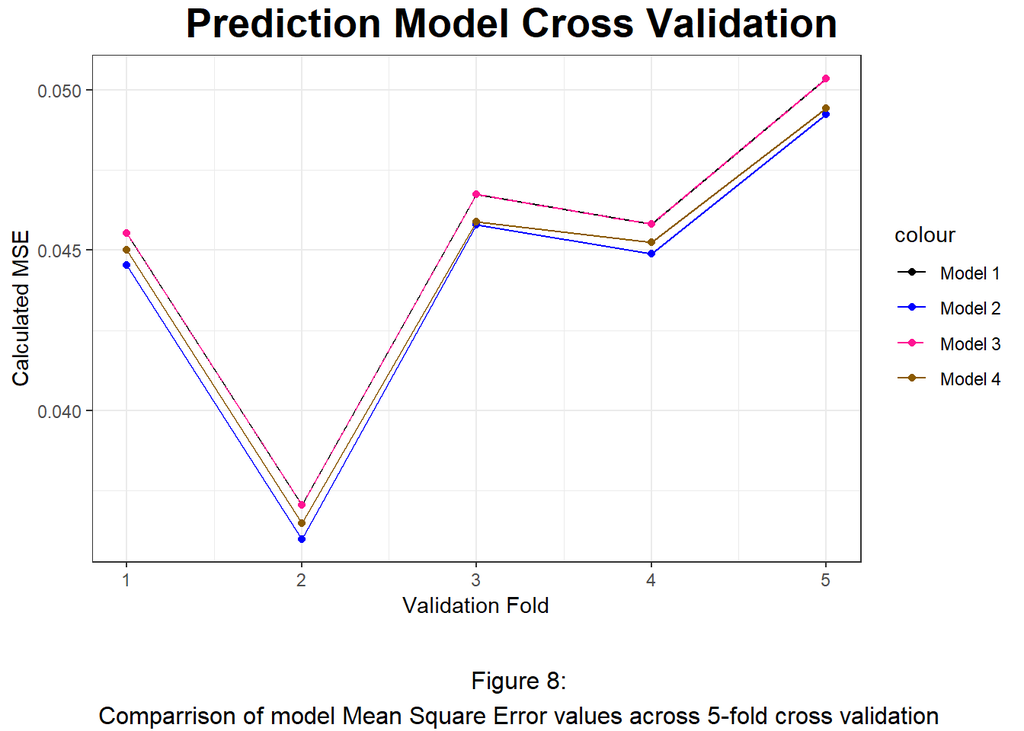

```r
grid.arrange(
  arrangeGrob(mse.mod1.plot, ncol = 1,nrow = 1),
  top = textGrob("Prediction Model Cross Validation", gp = gpar(fontsize = 20, fontface = "bold")),
  bottom = textGrob("
  Figure 8:
  Comparrison of model Mean Square Error values across 5-fold cross validation"))
```

```r
kable(l.mse, col.names = c("Model 1 (Full)", "Model 2 (PCA)", "Model 3 (Step-wise)", "Model 4 (RFE)"), caption = "Table 16:
      <br>Mean MSE values for each model calculated across 5 cross-validation runs") %>%
  kable_styling()
```

Table 16: Mean MSE values for each model calculated across 5 cross-validation runs

| Model 1 (Full) | Model 2 (PCA) | Model 3 (Step-wise) | Model 4 (RFE) |
| --- | --- | --- | --- |
| 0.0451025 | 0.044092 | 0.0451025 | 0.0444112 |

## 4.3 PCA Model Analysis & Evaluation

Once selected as the best fit linear regression prediction model, the PCA model (`Model 2`) was re-evaluated utilizing the test data rather than the training data to ensure accuracy and ensure the model was not over-fitted. As a part of the development of each PCA, the original variables were linearly combined to create these principal components, effectively setting each PC to be a unique combination of 6 normalized variables (Airport Distance, Number of Flights, Weather, Support Crews Available, Late Incoming Plane Arrival, & Baggage Loading Time).

```r
lm.pca.train <- lm(arr_delay ~ PC1 + cluster, data = train.data)
lm.pca.test <- test.data
lm.pca.test$arr_delay_pred <- predict(lm.pca.train, newdata = lm.pca.test)
lm.pca <- final.delay
lm.pca$arr_delay_pred <- predict(lm.pca.train, newdata = lm.pca)

rsquares.lin <- data.frame(
  Data = c("Training Data", "Test Data", "Full Delay Data"),
  R.squared = c(summary(lm.pca.train)$r.squared ,(cor(lm.pca.test$arr_delay, lm.pca.test$arr_delay_pred))**2,(cor(lm.pca$arr_delay, lm.pca$arr_delay_pred))**2)
)
shrinkage.lin <- rsquares.lin
shrinkage.lin$Shrinkage <- c("", rsquares.lin[1,2] - rsquares.lin[2,2], rsquares.lin[1,2] - rsquares.lin[3,2])

shrinkage.lin$rely <- NULL

for (i in 1:length(shrinkage.lin)){
  if(shrinkage.lin[i,3] == ""){
    n <-  ""}
  else if(shrinkage.lin[i,3] < 0.1){
    n <-  "Reliable Model"}
  else if(shrinkage.lin[i,3] > 0.9){
    n <-  "Very Unreliable"}
  else {n  <-  "Potentially Reliable"}

  shrinkage.lin$rely[i] <- n
}



kable(summary(lm.pca.train)$coefficients, col.names = c("Estimate", "Std. Error", "t value", "Pr(> I t I)"), caption = "Table 17:
      <br>Regression coefficients for linear regression prediction model 2 (PCA) run on <b>test data</b>") %>%
  kable_styling()
```

|  | Estimate | Std. Error | t value | Pr(> I t I) |
| --- | --- | --- | --- | --- |
| (Intercept) | 0.3660901 | 0.0074979 | 48.825947 | 0.0000000 |
| PC1 | 0.0903510 | 0.0015904 | 56.810698 | 0.0000000 |
| cluster | 0.0166348 | 0.0057361 | 2.900037 | 0.0037595 |

As captured below in `Table 18` the calculated $R^2$ values for `Model 2` as fit to the training data, test data, and full model delay data indicate `Model 2` is a good fit for Overall Flight Delay prediction. The shrinkage was calculated for both the test data and the full delay data to measure the reliability of the prediction model. Utilizing the standard accepted cutoff of $Shrinkage < 0.1$, the linear regression model, `Model 2` (above equations) was found to be reliable as a prediction model for overall flight delays.

```r
kable(shrinkage.lin, col.names = c("Data Utilized", "R$^2$ Value", "Calculated Shrinkage", "Reliability"),  caption = "Table 18:
      <br>Assessment of model fit and reliability") %>%
  kable_styling()
```

Table 18: Assessment of model fit and reliability

| Data Utilized | R$^2$ Value | Calculated Shrinkage | Reliability |
| --- | --- | --- | --- |
| Training Data | 0.7526599 |  |  |
| Test Data | 0.7717050 | -0.0190451144868257 | Reliable Model |
| Full Delay Data | 0.7564583 | -0.00379841841295325 | Reliable Model |

In reviewing the residual plots, QQ plots, and Cook’s distance as obtained from model 2 run on the test data the following information was obtained:

- While there is a minor curve plotted in the Residuals vs. Fitted plot, the curve is minor ranging from 0.0 to 0.1
- The Residual vs. Fitted plot demonstrates a random scatter centered around y=0 indicating the assumption of linear regression that the residuals are normally distributed with a mean of 0 is met
- The Q-Q plot indicates a near perfect match between the residuals distribution and a normal distribution, proving the assumption of linear regression that the residuals are normally distributed is met
- The Scale-location plot demonstrates a random scatter of all residuals indicating that the assumption of linear regression that the residuals posses homoscedasticity (constant variance) is met
- The Residuals vs Leverage (Cook’s Distance) plot indicates that all values are within the Cook’s Distance therefore ensuring no variables are truly influential / outlier residuals

These findings indicate that the linear regression prediction model (`Figure 9`) is a good fit for the Overall Flight Delay data. As this model is a good fit and meets all assumptions of linear regression, this model has proven useful for live prediction of overall flight delay & determination of focus in airline budgets and staff to preemptively mitigate overall flight delays.

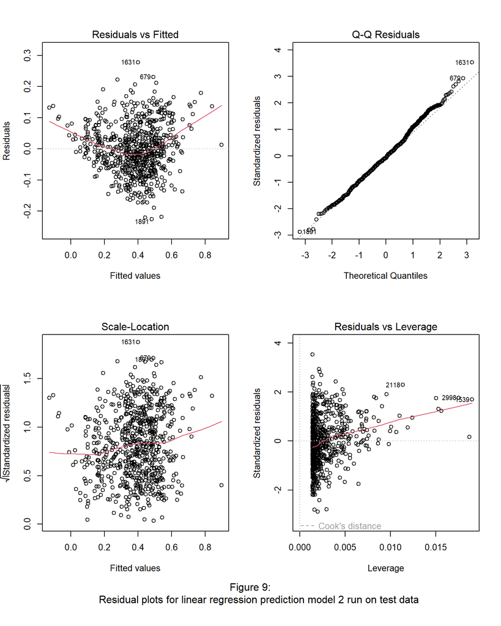

```r
lm.pca.test.plots <- lm(arr_delay ~ arr_delay_pred, data = lm.pca.test)

par(mfrow = c(2,2),oma = c(4, 0, 0, 0))
plot(lm.pca.test.plots)
mtext("Figure 9:
      Residual plots for linear regression prediction model 2 run on test data", side= 1, line = 1, outer=TRUE)
```

# 5 Logistic Regression Model for Live Arrival Delay Prediction

Live determining predicted delay times is imperative for airport planning and resourcing to reduce a downstream cascade of delayed flights throughout the entire flight network. In order to efficiently pivot to ensure a cascade does not occur, it is imperative airlines and airports can accurately and quickly feed data into prediction models to obtain overall delay estimates. As the linear regression model created is computationally heavy, a second logistic regression model was created to predict an airline’s k-Means cluster ID to reduce overall time and computational burden. This will allow for reduced computational input to calculate the overall flight delay utilizing the linear regression equation (`Model 2`) as outlined above in section 4. Linear Regression Model for Arrival Delay Prediction. The correlation between Overall Flight Delay and k-Means Cluster ID was checked and a strong negative linear relationship was identified, highlighting the importance in rapidly determine this k-Means Cluster ID with minimal computational burden to allow for live Overall Flight Delay prediction.

```r
corr.delay.clust <- data.frame(
  Correlation =  cor(final.delay$arr_delay, final.delay$cluster)
)

kable(corr.delay.clust, caption = "Table 19:
      <br>Correlation between Overall Flight Delay and k-Means Cluster ID") %>%
  kable_styling()
```

Table 19: Correlation between Overall Flight Delay and k-Means Cluster ID

| Correlation |
| --- |
| -0.6852907 |

## 5.1 Regression Model Creation

In order to determine the best logistic regression prediction model for use in k-Means cluster ID prediction to improve live Overall Flight Delay prediction times. The following models were developed and analyzed to determine the best fit model to conduct these tests and determinations:

- **Model 1:** Full regression model (Cluster ~ All Variables in `Final.Delay` data set)
  - The full model was selected to serve as an initial analysis and point of reference for models 2 - 4.
- **Model 2:** Step-wise automated selection regression model (Cluster ~ Late Incoming Planes)
  - The step-wise automated selection model was chosen to remove potential human bias and error in creating the best fit prediction model. Both forward and backwards step-wise analysis was completed to identify the optimal model for prediction.
- **Model 3:** External Conditions Model (Cluster ~ Late Incoming Planes + Weather + Number of Flights)
  - This model was created to predict based on non-staffing related airport conditions
- **Model 4:** Staff Model (Cluster ~ Support Crews Available + Baggage Loading Time)
  - This model was created to predict based on staffing related airport conditions

```r
train.data$cluster <- as.numeric(train.data$cluster)
test.data$cluster <- as.numeric(test.data$cluster)

train.data$cluster2 <- NULL
for(i in 1:length(train.data)){
  if(train.data$cluster[i] == 1){
    n <- 0}
  else {n <- 1}

  train.data$cluster2[i] <- n
}

test.data$cluster2 <- NULL
for(i in 1:length(train.data)){
  if(test.data$cluster[i] == 1){
    n <- 0}
  else {n <- 1}

  test.data$cluster2[i] <- n
}

final.delay$cluster2 <- NULL
for(i in 1:length(final.delay)){
  if(final.delay$cluster[i] == 1){
    n <- 0}
  else {n <- 1}

  final.delay$cluster2[i] <- n
}
fm.train <- train.data[-12]
qm.train <- train.data[-c(8:12)]

full.model.logit <- glm(cluster2 ~., data = fm.train, family = "binomial")
quick.model.logit <- glm(cluster2~., data = qm.train, family = "binomial")

logit.step <- stepAIC(full.model.logit, direction = "both", trace = FALSE)
logit.qstep <- stepAIC(quick.model.logit, direction = "both", trace = FALSE)

step.logit <- glm(cluster2 ~ late_incoming, data = train.data, family = "binomial")

ext.logit <- glm(cluster2 ~ weather*late_incoming*num_flights, data = train.data, family = "binomial")

staff.logit <- glm(cluster2 ~ sup_crew*baggage, data = train.data, family = "binomial")
```

## 5.2 Model Comparrison

```r
aic.comp <- data.frame(
  Model = c("Full Model (Model 1)", "Stepwise Model (Model 2)", "External Cond. Model (Model 3)", "Staff Model (Model 4)"),
  AIC = c(full.model.logit$aic, step.logit$aic, ext.logit$aic, staff.logit$aic)
)

kable(aic.comp, caption = "Table 20:
      <br>Comparrison of calculated AIC values for proposed logistic regression prediction models for cluster ID") %>%
  kable_styling()
```

Table 20: Comparrison of calculated AIC values for proposed logistic regression prediction models for cluster ID

| Model | AIC |
| --- | --- |
| Full Model (Model 1) | 108.13419 |
| Stepwise Model (Model 2) | 98.77241 |
| External Cond. Model (Model 3) | 101.69402 |
| Staff Model (Model 4) | 102.39538 |

Finally the ROC (Receiver Operating Characteristic) curves for each prediction model were compared for a second visual representation of the comparison of true positive and false positive rates as well as the calculated area under the curve (AUC) measures below in `Figure 10`. As seen with the calculated AUC for `Model 3` the External Cond. Model demonstrates excellent prediction performance by the model. The best fit sensitivity and specificity values for use with the model and indicated in `Figure 10` with a yellow triangle and in `Table 21`. These cutoffs are then utilized for weighting of the false positive and true positive rates when utilizing the probabilities as output in the binary logistic regression model to predict the cluster ID without full PCA and k-Means cluster ID creation.

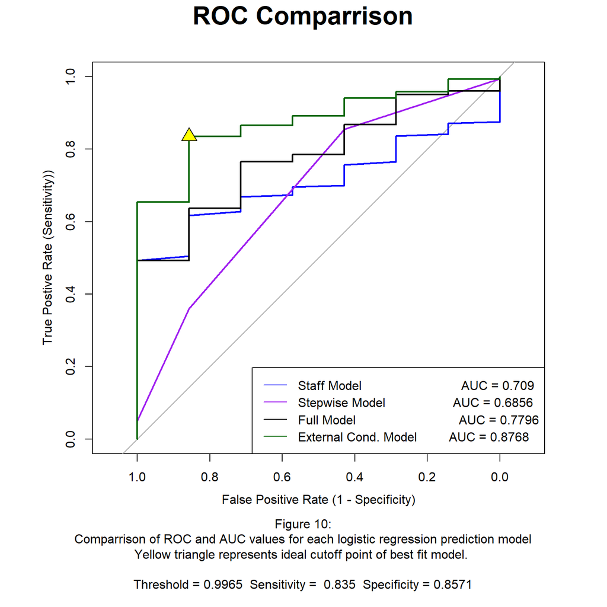

```r
#model predictions
ROC.step <- roc(step.logit$y, step.logit$fitted.values)

ROC.ext <- roc(ext.logit$y, ext.logit$fitted.values)

ROC.full <- roc(full.model.logit$y, full.model.logit$fitted.values)

ROC.staff <- roc(staff.logit$y, staff.logit$fitted.values)



roc.colors <- c("blue", "purple", "black", "darkgreen")
cp <- coords(ROC.ext, "best", ret = c("threshold", "sensitivity", "specificity"))

par(oma = c(6,2,2,2),  cex.main = 2)
plot.roc(ROC.staff, col = "blue", ylab = "True Postive Rate (Sensitivity))", xlab = "False Positive Rate (1 - Specificity)", lwd = 2)
plot.roc(ROC.step, col = "purple", add = TRUE, lwd = 2)
plot.roc(ROC.full, add = TRUE, lwd = 2)
plot.roc(ROC.ext, col = "darkgreen", add = TRUE, lwd = 2)
legend("bottomright", legend =
         c(paste(
             "Staff Model                            AUC =", round(ROC.staff$auc,4)),
           paste(
             "Stepwise Model                   AUC =", round(ROC.step$auc,4)),
           paste(
              "Full Model                             AUC =", round(ROC.full$auc, 4)),
           paste(
             "External Cond. Model         AUC =", round(ROC.ext$auc, 4))), col = roc.colors, lwd = 1)
title(main="ROC Comparrison", outer = T)
title(sub = paste("Figure 10:
Comparrison of ROC and AUC values for each logistic regression prediction model
Yellow triangle represents ideal cutoff point of best fit model.

Threshold =", round(cp$threshold,4), " Sensitivity = ", round(cp$sensitivity,4), " Specificity =", round(cp$specificity, 4)), outer = T, line=4)
points(x = cp$specificity, y = cp$sensitivity, pch = 24, bg = "yellow", cex = 2)
```

```r
kable(cp, caption = "Table 21:
      <br>Threshold and cutoff true positive and false positive rates", col.names = c("Threshold", "True Positive (Sensitivity)", "False Positive (1-Specificity)")) %>%
  kable_styling()
```

Table 21: Threshold and cutoff true positive and false positive rates

[output not shown]

# 6 Conclusions

In this analysis of global flight delay data, two prediction models were created for separate utilization purposes, both tuned to assist airlines and airports in reduction of overall flight delay data. The PCA based linear regression model proves to create a detailed tool for airlines to proactively plan staffing considerations, overall flight scheduling, and departmental budgets by predicting the impact of overall changes in the terms of average Overall Flight Delay times. As this model is of a high computational burden, a second model was created to predict the k-Means cluster ID utilized in the linear regression model for a rapid approach to live flight delay predictions. By first using the low computational burden logistic regression prediction model the predicted k-Means cluster ID can be fed into the linear regression prediction model while simultaneously dropping the PCA process to 1 variable and omitting the k-Means cluster ID creation to live predict flight delays. This will allow airports to predict downstream impacts of delays based on current airport conditions (weather, staff availability, average incoming flight delays, and number of flights at the airport that day). Through stacking these two robust prediction models airlines and airports should be more than equipped to predict delays live/before they happen and preemptively plan staffing and budgeting considerations for high travel days (ex: Christmas Eve) to reduce bottlenecks and downstream delays.